# How should we evaluate infectious disease forecasts?

CST, Heidelberg, 27 July 2026

Sebastian Funk

https://epiforecasts.io

[figure not shown]

[figure not shown]

## Why evaluate forecasts?

- Which models worked best?
- Which *kinds* of model work best?
- Are they better than simple heuristics?
- Did forecasts improve decision making?

## Proper scoring rules

$$\mathrm{CRPS}(F,y)=\mathbb{E}\,\lvert X-y\rvert \;-\; \tfrac12\,\mathbb{E}\,\lvert X-X'\rvert$$

[Gneiting & Raftery, *JASA*, 2007](https://doi.org/10.1198/016214506000001437)

## But infectious disease dynamics are peculiar

- Strong variation in targets: mean scores dominated by the high periods
- No clear reference standard
- Data revisions and reporting artifacts

## Epidemic dynamics are piecewise exponential

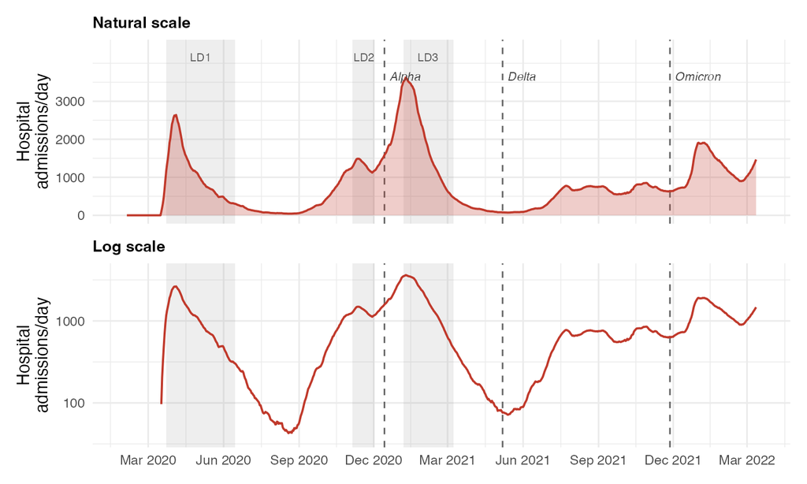

$I_t = R_t \sum_s g_s\, I_{t-s}$

$R_t \approx R$ over a phase $\Rightarrow I_t \approx I_0 e^{rt}$

# Scoring forecasts of infectious disease trajectories

## Two problems:

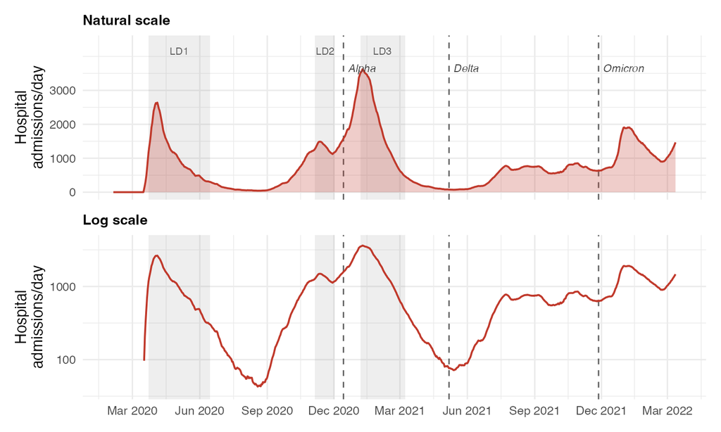

1. Error scales with the level of the data; scores dominated by high phases
2. Equal errors in growth rate cost unequally on the natural scale: overpredicting $r$ by $\delta$ costs $y\,(e^{\delta t}-1)$, underpredicting by $\delta$ costs only $y\,(1-e^{-\delta t})$

## Solution: Scoring on a transformed (log) scale

Take log of data and forecasts before scoring

$$\log \hat y - \log y = \log\frac{\hat y}{y} \approx \frac{\hat y - y}{y} \qquad \text{(relative error)}$$

$$y = y_0\, e^{\bar r t} \;\Rightarrow\; \log \hat y - \log y = t\,(\hat r - \bar r) \qquad \text{(growth-rate error)}$$

As a one-to-one transform this preserves propriety.

[Bosse et al., *PLOS Comput Biol*, 2023](https://doi.org/10.1371/journal.pcbi.1011393)

## Scoring log-transformed data/forecasts

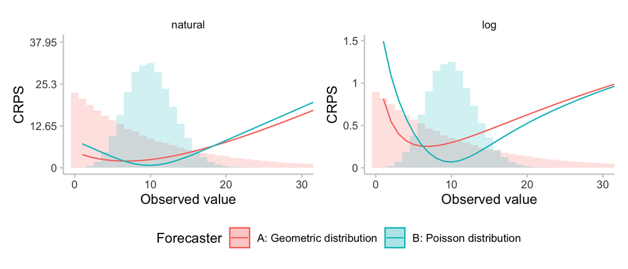

Scoring $\log(y)$ rewards relative error. Which forecaster “wins” flips with the scale.

[Bosse et al., *PLOS Comput Biol*, 2023](https://doi.org/10.1371/journal.pcbi.1011393)

## Changes ranking of forecasters

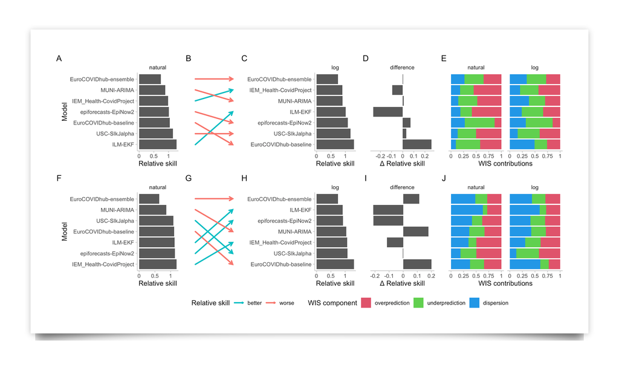

[Bosse et al., *PLOS Comput Biol*, 2023](https://doi.org/10.1371/journal.pcbi.1011393)

# Interpreting scores

## Hubs for collating forecasts from many different models

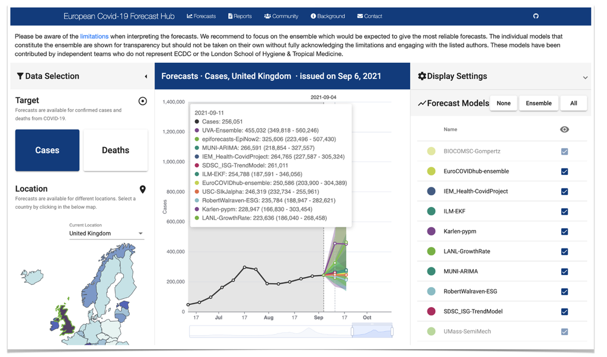

[Reich et al., *Am J Public Health*, 2022](https://doi.org/10.2105/AJPH.2022.306831)

## Two generating processes

Every score $S(F, y)$ is driven by two distinct processes:

- **Forecast-generating process**: model structure (mechanistic, statistical, ML, judgement), implementation, participation
- **Target-generating process**: epidemic dynamics (incidence level, trend, variant phase), observation noise, country, horizon

Raw scores conflate the two: **target difficulty** masks **model capability**.

## Drawing conclusions is hard

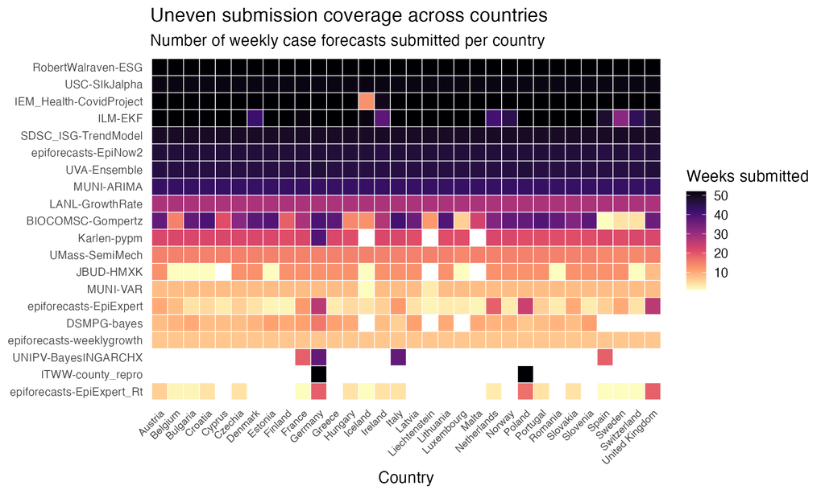

Raw comparisons fail because performance is confounded by:

- **Location & scale**: 32 countries with different populations and reporting
- **Epidemic difficulty**: incidence levels, trends, variant transitions, horizons
- **Uneven coverage**: teams submit intermittently or to specific sub-targets

## Treat the scores as data

```
  WIS ~ s(Method, bs="re")            # Model structure (of interest)
      + s(CountryTargets, bs="re")     # Multi vs single-country adaptation
      + s(Incidence)                   # Target difficulty (scale)
      + s(Trend, bs="re")              # Target difficulty (surges)
      + s(VariantPhase, bs="re")       # Target difficulty (immune escape)
      + s(Location, bs="re")           # Target difficulty (location)
      + s(Horizon, by=Model, bs="sz")  # Model-specific decay (shrunk)
      + s(Model, bs="re")              # Residual model implementation
```

**■** Model Capability (Forecast-generating) **■** Target Difficulty (Target-generating)

[Sherratt et al., *medRxiv*, 2025](https://doi.org/10.1101/2025.04.10.25325611)

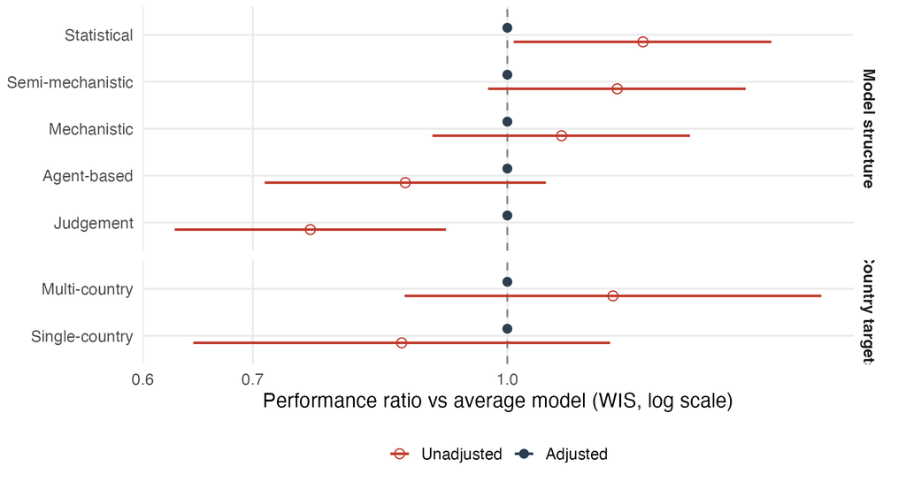

[Sherratt et al., *medRxiv*, 2025](https://doi.org/10.1101/2025.04.10.25325611)

The apparent differences between broad model classes disappeared after adjusting for target difficulty.

## Which target characteristics are associated with performance?

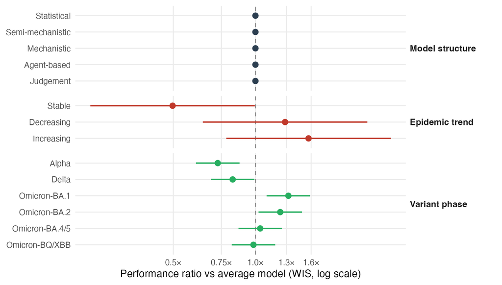

[Sherratt et al., *medRxiv*, 2025](https://doi.org/10.1101/2025.04.10.25325611)

# Exploring target difficulty

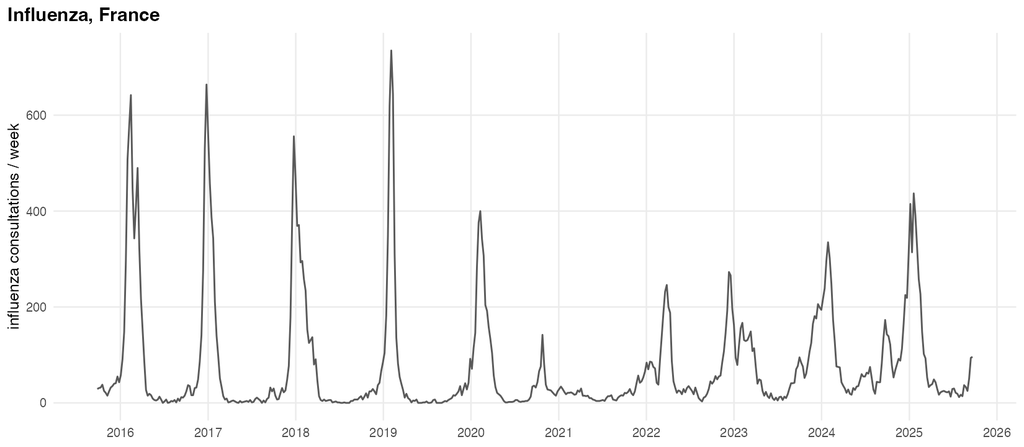

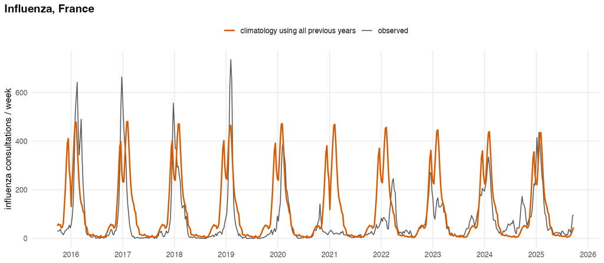

[Reich et al., *in prep*]

## What makes an epidemic predictable?

Statistical predictability is a combination of:

- **Autocorrelation (Past memory):** Short-horizon signal, driven by recent transmission and state-space persistence.
- **Seasonality (Calendar cycle):** Structure beyond the first few weeks, driven by annual calendar / environmental forcing.

## Climatology vs. autoregression

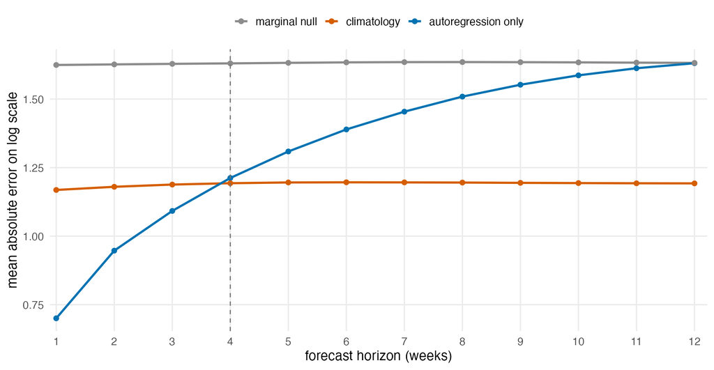

[Reich et al., *in prep*]

## Characterising the predictable signal

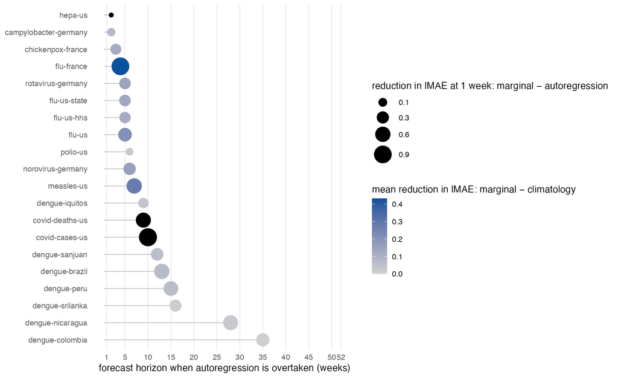

[Reich et al., *in prep*]

## Not always obvious which baseline to choose

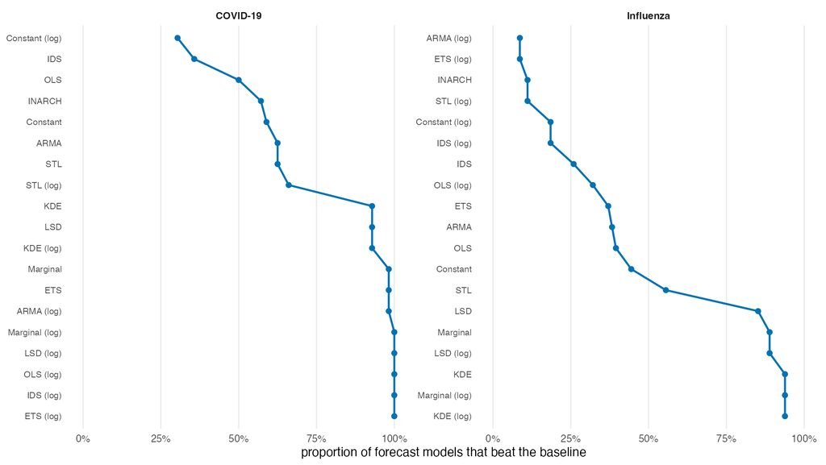

[Stapper et al., in prep]

# Subtleties in retrospective evaluation

## An impressive use of AI for forecasting?

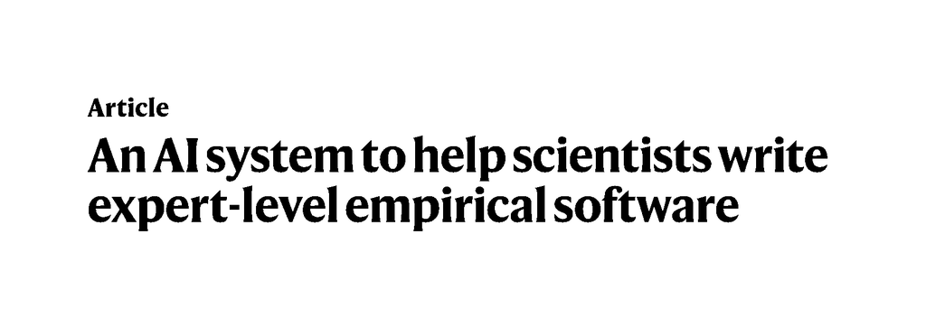

> Overall, our model achieved the highest performance with an average WIS of 26, outperforming the official CovidHub-ensemble’s average WIS of 29.

[Aygün et al., Nature, 2026](https://doi.org/10.1038/s41586-026-10658-6)

## Data revisions and a moving target

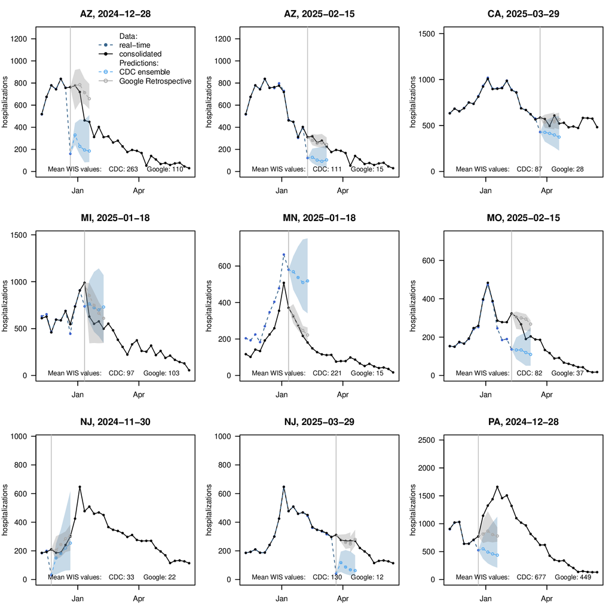

[Bracher & Funk, 2026, *in prep*]

## The reported advantage is concentrated in revised targets

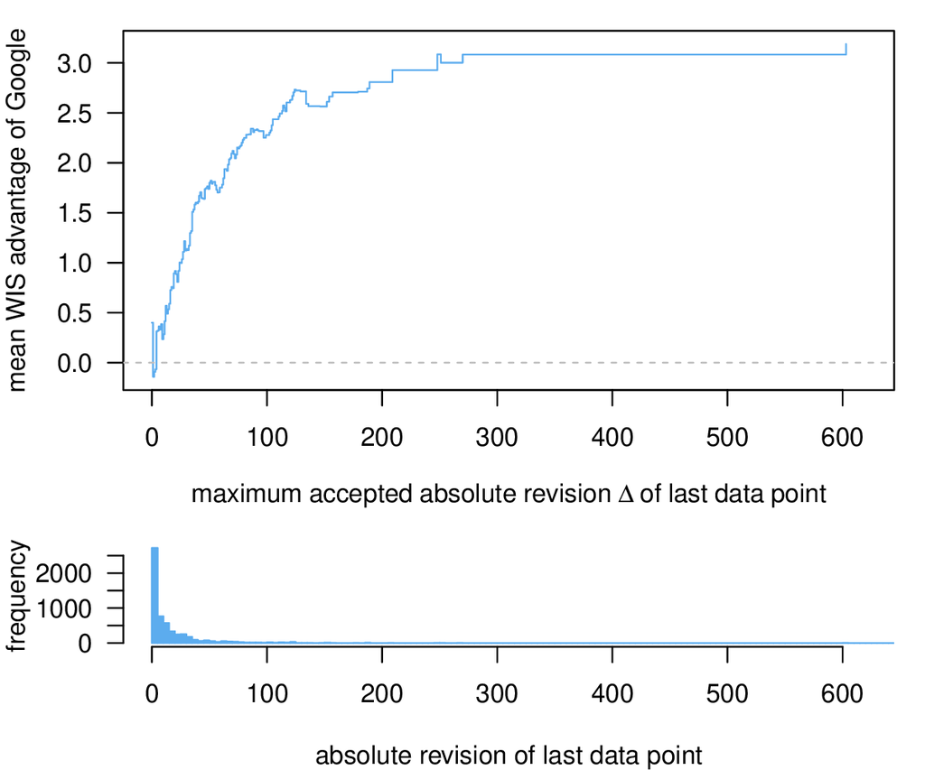

[Bracher & Funk, 2026, *in prep*]

# Are we evaluating what matters?

## Flu MetroCast Hub

- **Goal:** produce and evaluate local (sub-state) forecasts of the percentage of emergency-department visits due to influenza
- **Horizon:** 0–3 weeks ahead
- **Audience:** public health practitioners who had asked for more local forecasts
- **2025–26:** first full season; participation increased from 3 to 13 models
- Compare performance with state-level forecasts, identify the best-performing models, and gather feedback on their utility

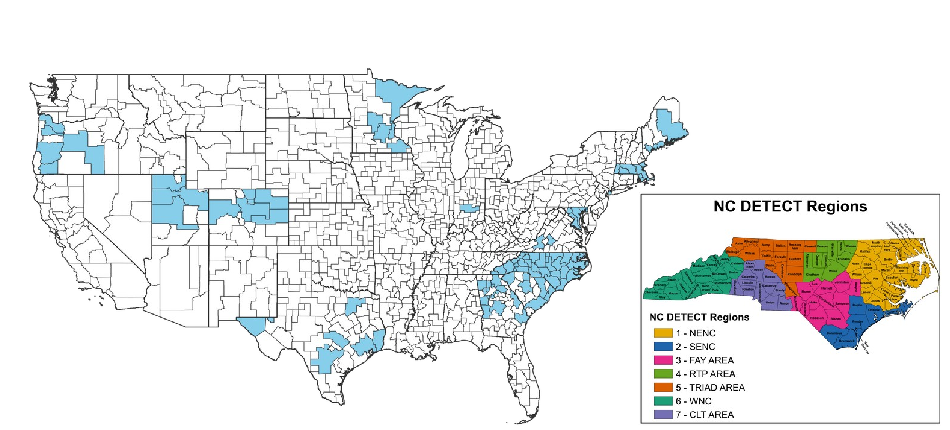

[Johnson et al., 2026, *in prep*]

## Shared consensus: models not performing well

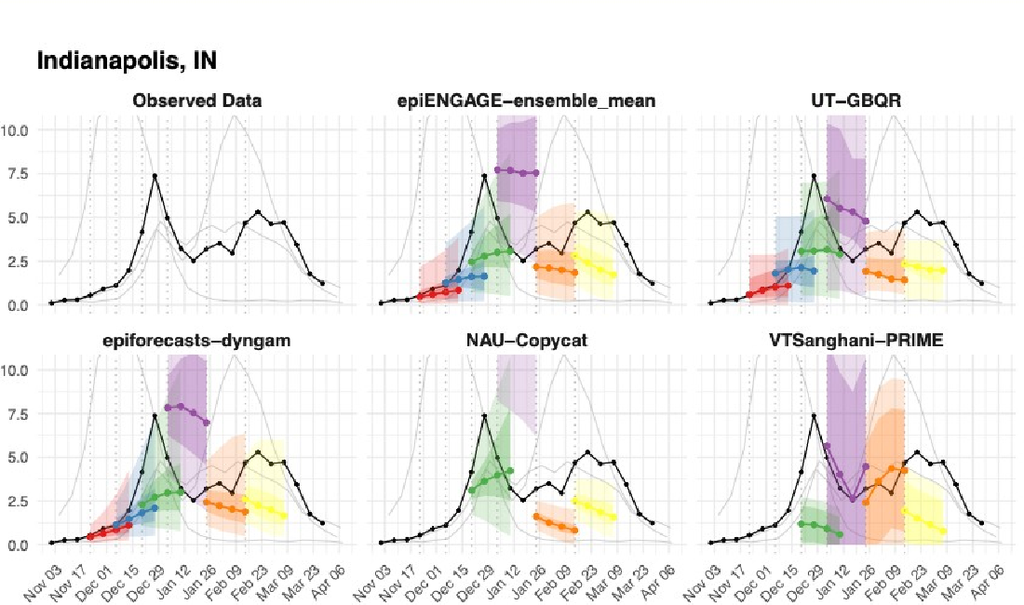

- Models missed the early and fast season onset
- Most models missed the peak
- Most models missed the second peak, where present

[Johnson et al., 2026, *in prep*]

## What do public health practitioners care about?

**Forecast features**

- Season onset
- Peak timing and magnitude
- Trend: increasing, decreasing or stable
- Probability of multiple peaks

**Not useful on its own**

- WIS relative to a baseline

**Current or potential uses**

- Communicating with leadership, the media and the public
- Recommending vaccines or masks
- Allocating or requesting additional staff and PPE

**There is an apparent misalignment between proper scoring metrics and what is interpretable or useful for public health.**

[Johnson et al., 2026, *in prep*]

## Scoring decisions formally

- **Allocation scoring**: score by the resource allocation implied by the forecast ([Gerding et al., 2024](https://arxiv.org/abs/2312.16201))
- **Decision-value framework**: evaluate forecasts against user risk preferences ($\alpha = C/L$) and event thresholds ([Mills et al., 2025](https://doi.org/10.1101/2025.07.20.25331802))

## Where does the loss function come from?

Decision scoring needs $L(y,a)$, or at least $\alpha = C/L$.

- **Which decision?** A loss exists only for a defined event, action, resource and horizon
- **Whose?** Rarely one person; costs and losses fall on different people, and are multi-objective
- **Said or done?** A stated preference need not match the action taken, or the regret afterwards

Can we elicit relevant loss functions?

## Summary

- Scoring scale can reverse which forecast appears best
- Apparent differences between broad model classes disappear after adjustment
- Recent history explains short-horizon predictability; climatology can extend it for seasonal diseases
- Revised data leak information into retrospective benchmarks
- Forecast accuracy can disagree with operational usefulness

# Thank you

Slides at

https://epiforecasts.io/slides/hits_cst_20260727.html